# Workflow: Mendelian disease-associated mutations

Bernardo Chombo-Álvarez

Miguel Ángel Varela Flores

2024-04-16

[Return back to project’s description](https://bernardochomboalvarez.github.io/GenomeMapping/)

# Reproducibility

```r
session_info()

# ─ Session info ─────────────────────────────
#  setting  value
#  version  R version 4.3.3 (2024-02-29)
#  os       Manjaro Linux
#  system   x86_64, linux-gnu
#  ui       RStudio
#  language (EN)
#  collate  en_US.UTF-8
#  ctype    en_US.UTF-8
#  tz       America/Mexico_City
#  date     2024-04-15
#  rstudio  2023.12.0+369 Ocean Storm (desktop)
#  pandoc   3.1.8 @ /usr/bin/ (via rmarkdown)
#
# ─ Packages ─────────────────────────────────
#  package     * version date (UTC) lib source
#  cli           3.6.2   2023-12-11 [1] CRAN (R 4.3.2)
#  colorspace    2.1-0   2023-01-23 [1] CRAN (R 4.3.1)
#  digest        0.6.34  2024-01-11 [1] CRAN (R 4.3.2)
#  dplyr       * 1.1.4   2023-11-17 [1] CRAN (R 4.3.2)
#  evaluate      0.23    2023-11-01 [1] CRAN (R 4.3.2)
#  fansi         1.0.6   2023-12-08 [1] CRAN (R 4.3.2)
#  farver        2.1.1   2022-07-06 [1] CRAN (R 4.3.1)
#  fastmap       1.1.1   2023-02-24 [1] CRAN (R 4.3.2)
#  generics      0.1.3   2022-07-05 [1] CRAN (R 4.3.2)
#  ggplot2     * 3.5.0   2024-02-23 [1] CRAN (R 4.3.2)
#  glue          1.7.0   2024-01-09 [1] CRAN (R 4.3.2)
#  gtable        0.3.4   2023-08-21 [1] CRAN (R 4.3.1)
#  htmltools     0.5.7   2023-11-03 [1] CRAN (R 4.3.2)
#  knitr         1.45    2023-10-30 [1] CRAN (R 4.3.2)
#  labeling      0.4.3   2023-08-29 [1] CRAN (R 4.3.1)
#  lifecycle     1.0.4   2023-11-07 [1] CRAN (R 4.3.2)
#  magrittr      2.0.3   2022-03-30 [1] CRAN (R 4.3.1)
#  munsell       0.5.0   2018-06-12 [1] CRAN (R 4.3.1)
#  pillar        1.9.0   2023-03-22 [1] CRAN (R 4.3.1)
#  pkgconfig     2.0.3   2019-09-22 [1] CRAN (R 4.3.1)
#  purrr         1.0.2   2023-08-10 [1] CRAN (R 4.3.2)
#  R6            2.5.1   2021-08-19 [1] CRAN (R 4.3.1)
#  rlang         1.1.3   2024-01-10 [1] CRAN (R 4.3.2)
#  rmarkdown     2.25    2023-09-18 [1] CRAN (R 4.3.2)
#  rstudioapi    0.15.0  2023-07-07 [1] CRAN (R 4.3.2)
#  scales        1.3.0   2023-11-28 [1] CRAN (R 4.3.2)
#  sessioninfo   1.2.2   2021-12-06 [1] CRAN (R 4.3.2)
#  tibble        3.2.1   2023-03-20 [1] CRAN (R 4.3.1)
#  tidyr         1.3.1   2024-01-24 [1] CRAN (R 4.3.2)
#  tidyselect    1.2.0   2022-10-10 [1] CRAN (R 4.3.2)
#  utf8          1.2.4   2023-10-22 [1] CRAN (R 4.3.1)
#  vctrs         0.6.5   2023-12-01 [1] CRAN (R 4.3.2)
#  withr         3.0.0   2024-01-16 [1] CRAN (R 4.3.2)
#  xfun          0.42    2024-02-08 [1] CRAN (R 4.3.2)
#  yaml          2.3.8   2023-12-11 [1] CRAN (R 4.3.2)
#
#  [1] /home/chombo/R/x86_64-pc-linux-gnu-library/4.3
#  [2] /usr/lib/R/library


#
# IMPORTANT!!!
# All the data was cleaned using basic Linux commands. The used files are in the data/ folder inside the repo
```

# Overview

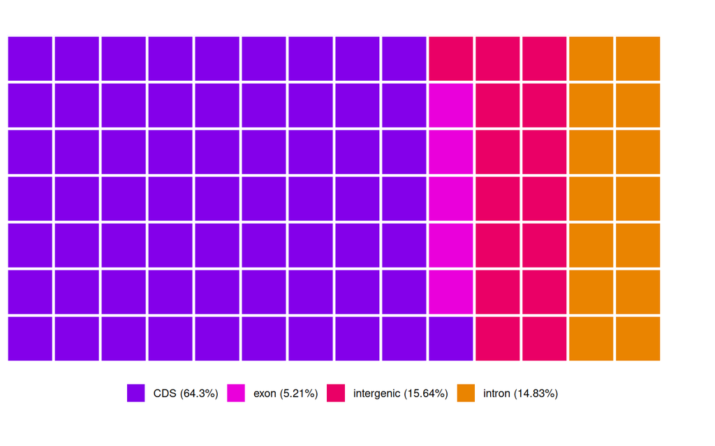

## Set intronic and intergenic regions

After examining the human genome’s .gff file, we noticed the lack of intronic and intergenic regions. To solve this problem, we realized that it was pretty easy to define each of these regions: an intron it is a region that goes from the end of an exon to the beginning of the next one, and an intergenic region goes from the end of a gene to the beginning of the next one. However, there’s the possibility of encounter genes inside genes or overlapped genes (and it’s the same scenario for the exons). To overcome this issue, we took into account the ending positions of each of the genes and of each of the exons, and defined an intronic or intergenic region if and only if the beginning of the next gene/exon was after the ending of the last gene/exon, the ending of the next gene/exon was after the maximum ending and more importantly, the ending of the next gene/exon was greater that the maximum ending registered at the time it’s being evaluated.

### Libraries

```r
library(dplyr)
```

### Code

```r
## Set working directory
setwd("/home/chombo/Downloads/Proyecto_Genomica_Humana/CHOMBO/data")

## Import the data
chr_names <- read.csv("chr_ids.csv",header = FALSE,sep = ",")
names(chr_names) <- c("chr","chr_id","stop")
chr_names <- chr_names %>%
    mutate(start = 1) %>%
    arrange("chr","chr_id","start","stop")
chr_ids <- chr_names$chr_id

## Human Genome GRHCh88.p14 assembly
grhc38_df <- read.table("GCF_000001405.40_GRCh38.p14_genomic.gff",skip = 9,header = FALSE,sep = "\t")
grhc38_df <- grhc38_df[,1:7]
names(grhc38_df) <- c("chr_id","source","feature","start","end","score","strand")
grhc38_df <- grhc38_df[!(grhc38_df$feature %in% c("region")),]
grhc38_df <- grhc38_df[(grhc38_df$chr_id %in% chr_ids),]

## Region search
full_data <- list()
for (i in 1:length(unique(chr_names$chr_id))) {
    ## Extract the data for only one chromosome
    chr <- chr_names[i,"chr_id"]
    chr_raw <- grhc38_df[grhc38_df$chr_id == chr,]

    ## Change the data type for "start" and "end" columns
    chr_raw$start <- as.numeric(chr_raw$start)
    chr_raw$end <- as.numeric(chr_raw$end)

    ## Reorder the dataframe and reset the index
    chr_raw <- chr_raw[order(chr_raw$start,decreasing = FALSE),]
    chr_raw <- chr_raw %>%
        select(chr_id,feature,start,end) %>%
        `rownames<-`(NULL)

    ## Create the object for intergenic regions
    intergenic_regions <- data_frame()

    ## Create a data subset only with the genes
    genes <- chr_raw[chr_raw$feature == "gene",]

    ## Define the limits of the chromosome coding region
    pos_start <- min(genes$start)
    pos_end <- max(genes$end)

    ## Create an intergenic region from the beginning of the chromosome to the start of the first gene
    intergenic_regions <- rbind(intergenic_regions,c(chr,"intergenic",1,pos_start - 1))

    ## Remove the data before the start and end coding regions
    ## Clean also other regions inside the genome
    ## IMPORTANT!! introns and exons: only the ones inside genes
    ## We are not counting the exons and introns from pseudogenes
    chr_raw <- chr_raw[!(chr_raw$start <= (pos_start - 1)) & !(chr_raw$end >= (pos_end + 1)),]  %>%
        `rownames<-`(NULL) %>%
        tibble::rowid_to_column("index")


    ## INTERGENIC REGION SEARCH
    ## There might be genes inside genes completely or partially so we search for the maximum gene length
    ## If the start position of the next gene is higher than the end of the previous one, and its end is higher than the previous' end and the max_end, then it's an intergenic region
    max_end <- genes[1,"end"]
    for (i in 2:length(genes$feature)) {
        ## If the previous gene's end is higher than the max_end, then we change it
        if (genes[i-1,"end"] >= max_end) {
            max_end <- genes[i-1,"end"]
        }

        ## Here we defint what it is an intergenic region
        if ((genes[i,"start"] > genes[i-1,"end"]) & (genes[i,"end"] > genes[i-1,"end"]) & (genes[i,"end"] >= max_end) & (genes[i,"start"] > max_end)) {
            intergenic <- c(chr, "intergenic", max_end + 1, genes[i,"start"] - 1)
            intergenic_regions <- rbind(intergenic_regions, intergenic)

            ## Additionally, we clean what's inside the chr_raw so that we get rid of everything that corresponds to an intergenic region
            pos_start <- max_end + 1
            pos_end <- genes[i, "start"] - 1
            chr_raw <- chr_raw[!((chr_raw$start >= pos_start) & (chr_raw$start <= pos_end) & (chr_raw$feature != "gene")),]
        }
    }

    ## We set the region corresponding to the end of the last gene and the end of the chromosome as an intergenic region
    end <- c(chr,"intergenic",max(genes$end) + 1,chr_names[chr_names$chr_id == chr,]$stop)
    intergenic_regions <- rbind(intergenic_regions,end)
    names(intergenic_regions) <- c("chr_id","feature","start","end")

    ## Merge the intergenic regions with the chromosome raw data
    chr_raw <- chr_raw %>% select(-index)
    chr_wintergen <- rbind(chr_raw,intergenic_regions)
    chr_wintergen$start <- as.numeric(chr_wintergen$start)
    chr_wintergen$end <- as.numeric(chr_wintergen$end)
    chr_wintergen <- chr_wintergen[order(chr_wintergen$start,decreasing = FALSE),]
    chr_wintergen <- chr_wintergen %>%
        select(chr_id,feature,start,end) %>%
        `rownames<-`(NULL)

    ## We then split the dataframe into different dataframes with CDS, exons and genes information
    cds <- chr_wintergen[chr_wintergen$feature == "CDS",]
    exons <- chr_wintergen[chr_wintergen$feature == "exon",]
    genes <- chr_wintergen[chr_wintergen$feature == "gene",] ## we repeat this so that we get no erros

    ## Now clean the merged dataframe so that we only stay with the exons and intergenic regions
    ## As every exon inside the data is now inside genes, we do this
    chr_wintergen <- chr_wintergen[(chr_wintergen$feature %in% c("intergenic","exon")),] %>%
        distinct()


    ## INTRONIC REGIONS
    ## With a similar approach for the intergenic regions, we extract the exons between intergenic regions
    ## We define an intron as the spaces between the first and last exons with the intergenic regions
    ## We look for exons that are not overlapped
    intronic_regions <- data_frame()
    for (i in 2:length(intergenic_regions$feature)) {
        ## Define the start position as the end of the previous intergenic region
        ## Define the end position as the start of the next intergenic region
        start <- as.numeric(intergenic_regions[i-1,"end"])
        end <- as.numeric(intergenic_regions[i,"start"])

        ## Extract the data, i.e. exons
        data <- exons[(exons$end < end & exons$start > start),] %>%
            `rownames<-`(NULL)

        ## In case there were no exons, we continue
        if (length(data$feature) == 0) {
            next
        }

        ## If there was a space between the first exon and the end of the previous intergenic region
        if (start - data[1,"start"] <= -2) {
            intron <- c(chr, "intron", start + 1, data[1,"start"] - 1)
            intronic_regions <- rbind(intronic_regions, intron)
        }

        ## If there was a space between the last exon and the beginning of the next intergenic region
        if (data[length(data$feature),"end"] - end <= -2) {
            intron <- c(chr, "intron", data[length(data$feature),"end"] + 1, end - 1)
            intronic_regions <- rbind(intronic_regions, intron)
        }

        ## If there was only one exon, we continue, else, the same exact logic for intergenic regions
        if (length(data$feature) == 1) {
            next
        } else {
            max_end <- data[1,"end"]
            for (i in 2:length(data$feature)) {
                ## Define the max_end
                if (data[i-1,"end"] >= max_end) {
                    max_end <- data[i-1,"end"]
                }

                ## Look for intronic regions
                if ((data[i,"start"] > data[i-1,"end"]) & (data[i,"end"] > data[i-1,"end"]) & (data[i,"end"] >= max_end) & (data[i,"start"] > max_end)) {
                    intron <- c(chr, "intron", max_end + 1, data[i,"start"] - 1)
                    intronic_regions <- rbind(intronic_regions, intron)
                }
            }
        }
    }
    names(intronic_regions) <- c("chr_id","feature","start","end")

    ## Merge the complete data for each chromosome
    complete <- rbind(genes,chr_wintergen,cds,exons,intronic_regions)
    complete$start <- as.numeric(complete$start)
    complete$end <- as.numeric(complete$end)
    complete <- complete[order(complete$start),] %>%
        `rownames<-`(NULL)

    ## Append them in a list
    full_data[[chr]] <- complete
}

## Transform the list
grhc_complete <- do.call(rbind, full_data) %>%
    `rownames<-`(NULL)

## Save the data
write.csv(grhc_complete,file = "grhc38_complete.csv",row.names = FALSE,col.names = FALSE,quote = FALSE)

## Save the data for each of the chromosomes
grhc_complete <- grhc_complete[order(grhc_complete$chr_id),]
for (chr in unique(grhc_complete$chr_id)) {
    data <- grhc_complete[grhc_complete$chr_id == chr,]
    data <- data[order(data$start),]
    write.csv(data,file = paste0(chr,"_data.csv"),row.names = FALSE,col.names = FALSE,quote = FALSE)

}
```

## Genome Mapping

For the genome mapping, we used the *divide et vince* principle. First, we divided the data in subsets for each chromosome; then, each subset was divided into another subsets determined by the four categories. Until then, each of the mutations for each chromosome was mapped in this second subset. This approach is thought to be hierarchical and stratified. It is important to remark that all of the mutations were mapped.

### Libraries

```r
library(dplyr)
library(ggplot2)
```

### Code

```r
## Set working directory
setwd("/home/chombo/Downloads/Proyecto_Genomica_Humana/CHOMBO/data")

## Import the data
## Chromosomes namnes
chr_names <- read.csv("chr_ids.csv",header = FALSE,sep = ",")
names(chr_names) <- c("chr","chr_id","length")
chr_ids <- chr_names$chr_id

## Mutations data
clinvar_df <- read.table("clinvar.cleaned.tsv",header = FALSE,sep = "\t")
names(clinvar_df) <- c("gene","chr","position","id")
clinvar_df <- merge(clinvar_df,chr_names, by = "chr", all.x = TRUE)
clinvar_df$chr_id <- as.character(clinvar_df$chr_id)
clinvar_df <- clinvar_df %>%
    select(-c("id","length"))

## Human Genome annotation data
grhc_complete <- read.csv("grhc38_complete.csv",header = TRUE,sep = ",")
grhc_complete$start <- as.numeric(grhc_complete$start)
grhc_complete$end <- as.numeric(grhc_complete$end)

## Characterize the mutations
## Divide the data for each of the chromosomes
mutations <- list()
for (chr in unique(grhc_complete$chr_id)) {
    ## Create a reference for each one of the chromosomes
    chr_ref <- grhc_complete %>%
        filter(chr_id == chr) %>%
        arrange(start) %>%
        distinct() %>%
        `rownames<-`(NULL) %>%
        tibble::rowid_to_column("index")

    ## Create a data subset for the mutations of each chromosomes
    chr_mut <- clinvar_df[clinvar_df$chr_id == chr,] %>%
        arrange(position) %>%
        `rownames<-`(NULL) %>%
        tibble::rowid_to_column("index")

    ## Map all the mutations in the reference genome data subset
    mapped <- data_frame()
    known_indexes <- c()
    unknown_indexes <- c()
    categories <- c("intergenic","CDS","intron","exon","gene") ## Each of this categories are hierarchically ordered
    for (category in categories) {
        ## Divide again the subset by each of the four categories
        reference <- chr_ref %>% filter(feature == category)

        ## Now itterate all the subset of mutations for each chromosome
        for (i in 1:length(chr_mut$position)) {
            ## Skip known indexes
            if (i %in% known_indexes) {
                next
            }

            ## Search index in the reference (only one result should be TRUE)
            logic_res <- with(reference, start <= chr_mut[i,"position"] & end >= chr_mut[i,"position"])

            ## Store the indexes of the TRUE result
            indexes <- which(logic_res)

            ## Continue if no index is found
            if (length(indexes) == 0) {
                next
            } else {
                ## Create a vector with the index and the category
                mapped <- rbind(mapped,c(i,category))
                known_indexes <- c(known_indexes,i)
            }
        }
    }

    ## If there is any unknown index, compare it against the mutations indexes
    unknown_indexes <- chr_mut[!(chr_mut$index %in% known_indexes),"index"] %>%
        unname()

    ## Create a dataframe with the unknown indexes if any
    if (length(unknown_indexes) != 0) {
        unmapped <- cbind(unknown_indexes,"UNMAPPED")
        unmapped <- as.data.frame(unmapped)
        names(unmapped) <- c("index","feature")
        unmapped$index <- as.numeric(unmapped$index)
        complete <- rbind(mapped,unmapped)
        complete <- complete[order(complete$index),]
    } else {
        ## Merge the known indexes
        complete <- mapped
        names(complete) <- c("index","feature")
        complete$index <- as.numeric(complete$index)
        complete <- complete[order(complete$index),]
    }

    ## Add the chromosome's id data
    complete <- merge(chr_mut,complete,by = "index") %>%
        select(-index) %>%
        `rownames<-`(NULL)

    ## Merge the data
    mutations[[chr]] <- complete

}

## Join all the data
mutations <- do.call(rbind, mutations) %>%
    `rownames<-`(NULL)
mutations <- merge(mutations,chr_names, by="chr_id")
mutations$chr <- paste0("Chr ",mutations$chr)
mutations <- mutations %>%
    select(-c("chr.y","length")) %>%
    mutate(chr = paste(chr,chr.x,sep = " ")) %>%
    select(-chr.x) %>%
    distinct()
```

## Data arrangement and Plotting

Finally, once he had our data completed, we proceeded to rearrange it. A contingency table was generated and it is the one that it’s shown below. With the help of **ggplot2** R library, we generated the figures shown.

### Libraries

```r
library(dplyr)
library(ggplot2)
```

### Data arrangement

```r
## Set working directory
setwd("/home/chombo/Downloads/Proyecto_Genomica_Humana/CHOMBO/data")

## Import the data
chr_names <- read.csv("chr_ids.csv",header = FALSE,sep = ",")
names(chr_names) <- c("chr","chr_id","length")
chr_ids <- chr_names$chr_id

mutations <- read.csv("mutations_complete.csv",header = TRUE,sep = ",")
mutations <- mutations %>%
    distinct() %>%
    select(-c("position","gene","chr"))

## Extract the mutations per category for each of the chromosomes
mut_arranged <- mutations %>%
    mutate(count = 1) %>%
    group_by(chr_id, feature) %>%
    summarize(count = sum(count)) %>%
    ungroup()

## Make a contingency table with the four features as columns and the counts for each one for each of the chromosomes
mut_contingence <- tidyr::pivot_wider(data = mut_arranged, names_from = feature, values_from = count)
mut_contingence <- replace(mut_contingence, is.na(mut_contingence), 0) %>%
    mutate(total = CDS+exon+intergenic+intron)

## Modify the contingency table so that now it has the percentages
mut_contingence.per <- mut_contingence %>%
    mutate(CDS = trunc((CDS/total)*100*10^2)/10^2,
           exon = trunc((exon/total)*100*10^2)/10^2,
           intergenic = trunc((intergenic/total)*100*10^2)/10^2,
           intron = trunc((intron/total)*100*10^2)/10^2)

## Clear the contingency table with percentages
mut_contingence.per <- merge(mut_contingence.per,chr_names, by = "chr_id") %>%
    select(-length) %>%
    mutate(id = paste0("Chr ",chr," (",total,")")) %>%
    select(-c("chr_id","chr","total"))

## Expand the table into two columns: id and feature
mut_expanded <- tidyr::pivot_longer(data = mut_contingence.per,
                                    cols = -id,
                                    names_to = "feature",
                                    values_to = "count")

## Create a dataframe with the totasl counts for each feature
feature_counts <- as.data.frame(table(mutations$feature))
names(feature_counts) <- c("feature","count")
feature_counts <- feature_counts %>%
    mutate(percentage = (count/sum(count))*100) %>%
    mutate(percentage = trunc(percentage*10^2)/10^2)
```

### Plotting

First, an overview of the mutations. There were 1,015,540 mutations identified (only considering the unique ones, i.e. unique positions, despite there were more than one possible mutation in a single position). Moreover, there were 653,005 identified mutations in coding regions (CDS), 52,925 in exons, 158,924 in intergenic regions and 150,686 in introns.

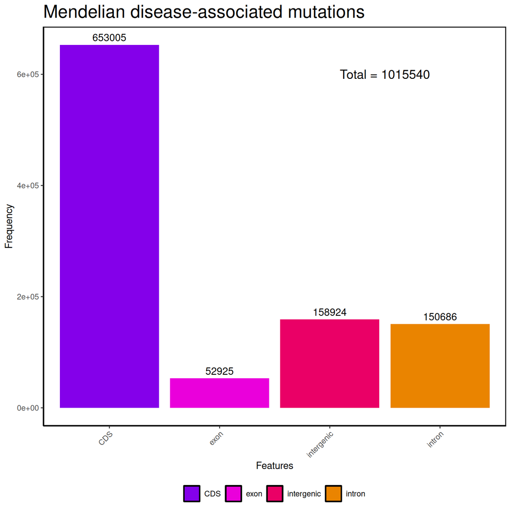

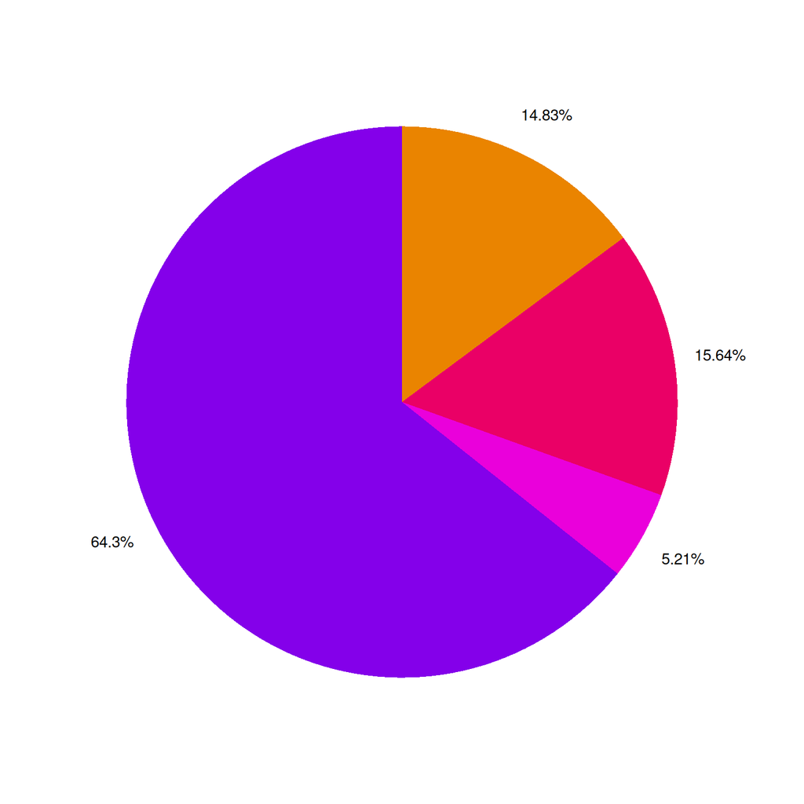

Here there are plots for each of the chromosomes and their distribution. Each percentage of the pie charts are adjusted to the amount of data each one of them has. For a better understanding, a contingency table that contains all the data per category, per chromosome is displayed below.

```
##          chr_id   CDS exon intergenic intron  total
## 1  NC_000001.11 57285 4027       9227  14294  84833
## 2  NC_000002.12 74811 5033      14177  16284 110305
## 3  NC_000003.12 28318 3161      12482   6130  50091
## 4  NC_000004.12 22894 2442        178   5553  31067
## 5  NC_000005.10 34490 3650       5903   7276  51319
## 6  NC_000006.12 27708 1905       7001   5683  42297
## 7  NC_000007.14 29404 1826       7645   7635  46510
## 8  NC_000008.11 23102 1517      10786   4482  39887
## 9  NC_000009.12 28454 2896      10049   6478  47877
## 10 NC_000010.11 21749 2352       2901   4805  31807
## 11 NC_000011.10 40052 3325       3621   9944  56942
## 12 NC_000012.12 21650 2025      13966   4764  42405
## 13 NC_000013.11 14543 1454        128   3048  19173
## 14  NC_000014.9 25773 1774        645   5665  33857
## 15 NC_000015.10 15616 1311      15191   3629  35747
## 16 NC_000016.10 42259 2904       8182   9717  63062
## 17 NC_000017.11 48876 3702       3229  11788  67595
## 18 NC_000018.10 10058  921       2531   2476  15986
## 19 NC_000019.10 28844 2195       5543   7715  44297
## 20 NC_000020.11 12205 1306       2243   3247  19001
## 21  NC_000021.9  8860  635        264   2110  11869
## 22 NC_000022.11 12588 1323       2007   3209  19127
## 23 NC_000023.11 22481  859      19978   4754  48072
## 24 NC_000024.10     4    0         35      0     39
## 25  NC_012920.1   981  382       1012      0   2375
```

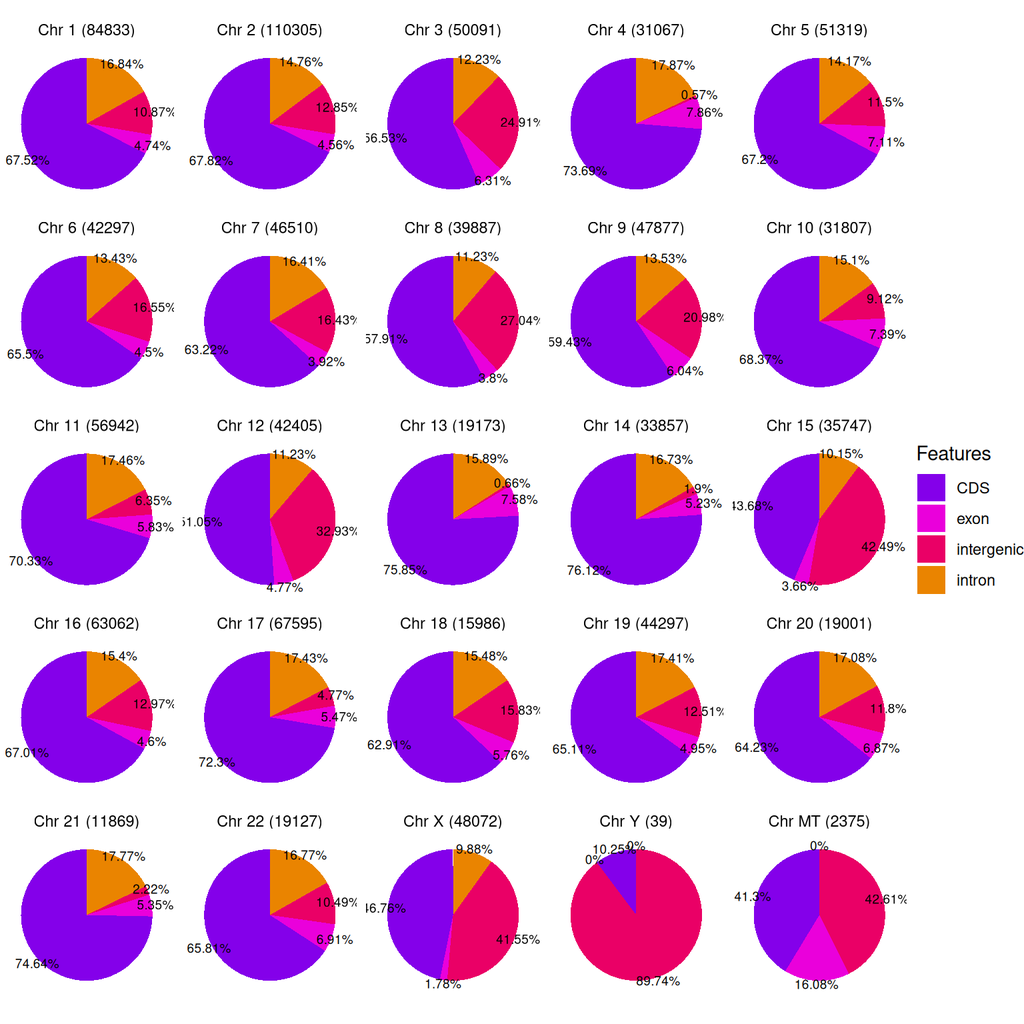

# References

1. Landrum, M. J., Chitipiralla, S., Brown, G. R., Chen, C., Gu, B., Hart, J., Hoffman, D., Jang, W., Kaur, K., Liu, C., Lyoshin, V., Maddipatla, Z., Maiti, R., Mitchell, J., O’Leary, N., Riley, G. R., Shi, W., Zhou, G., Schneider, V., Maglott, D., Holmes, J.B., Kattman, B. L. ClinVar: improvements to accessing data. Nucleic Acids Res. 2020;48(D1):D835-D844. doi: 10.1093/nar/gkz972. [PubMed PMID:31777943]
2. UCSC Genome Browser: Kent WJ, Sugnet CW, Furey TS, Roskin KM, Pringle TH, Zahler AM, Haussler D. The human genome browser at UCSC. Genome Res. 2002 Jun;12(6):996-1006.